# COVID-19: A Midwestern Reporting Project of WNIN and the University of Evansville

Milwaukee Metropolitan COVID-19 Data

## Introduction

The COVID-19 pandemic disproportionately impacts lower-income communities. The Milwaukee Metropolitan area, consisting of Milwaukee, Washington, Waukesha, and Ozaukee counties, exemplifies this disparity. Milwaukee County, which has a much greater non-white population percentage and a lower median household income than the other metropolitan counties, experiences more cases and deaths per 100,000 people than the rest of the metropolitan counties. When taking into consideration conditions or demographics pre-exposed to death from COVID-19, smoking is much more prevalent in Milwaukee County, which could explain some of the difference in deaths between counties. However, the average age in Milwaukee County is much lower than the other counties, which is surprising given the rate at which individuals 65 and older die from COVID in comparison to the rest of society. Additionally, public transportation use appeared to be tied to higher COVID-19 rates in Milwaukee County. Unfortunately, downloadable ZIP code data for Milwaukee was not able to be found at this time, so a more specific analysis could not be performed.

## Case Rates

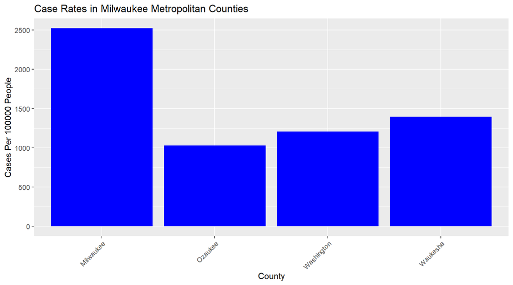

Case rates are much higher in Milwaukee County compared to the other three Milwaukee metropolitan counties.

## Death Rates

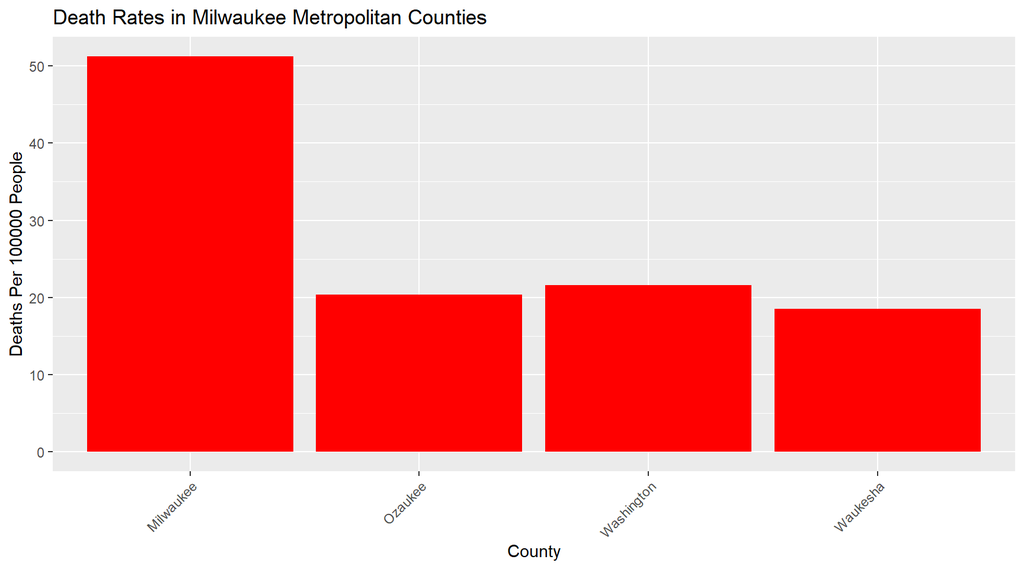

Death rates are much higher in Milwaukee County.

## White Population

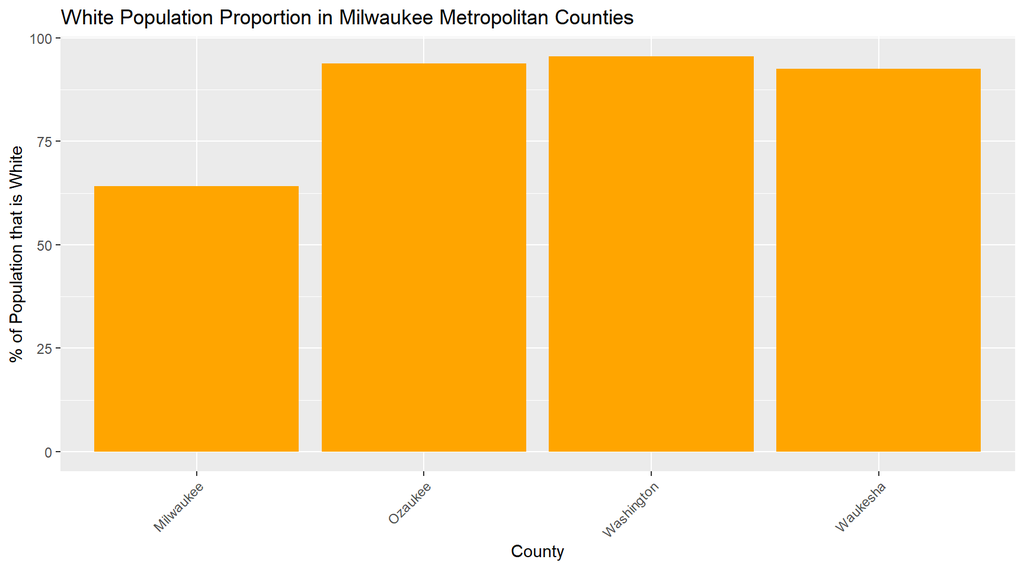

COVID is known to affect minority communities disproportionately. There are fewer white people living in Milwaukee County, where we previously saw that there are higher case and death rates.

## Income Data

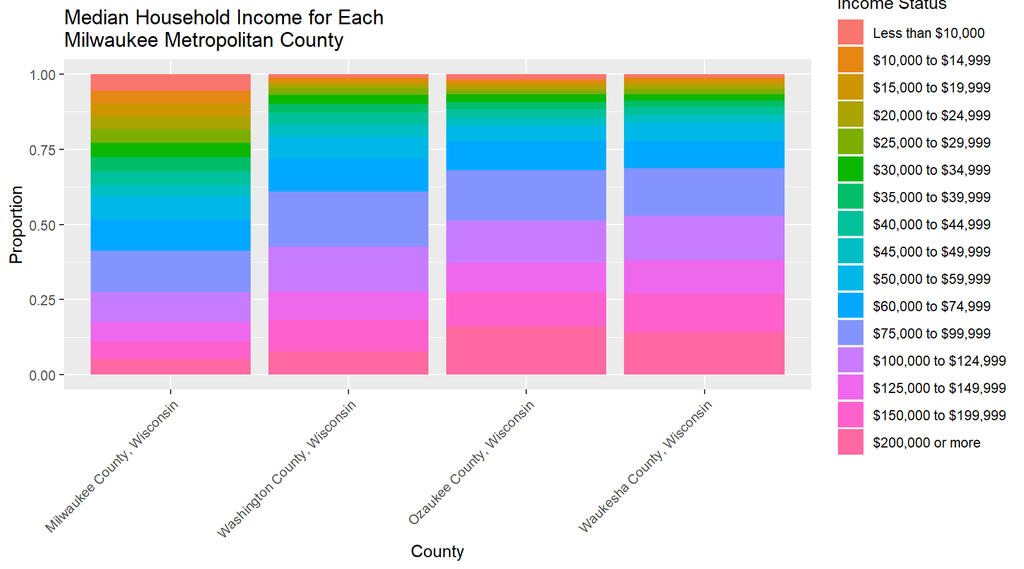

COVID is known to affect poorer populations more drastically, and Milwaukee County is poorer and more affected by COVID than the other metropolitan counties.

## Smoking Data

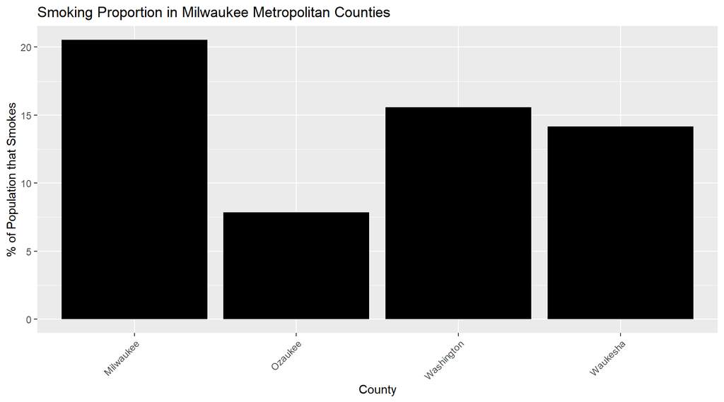

COVID affects the respiratory system, and citizens in Milwaukee County smoke at higher rates. This might explain some of the higher death rate in Milwaukee.

## Age

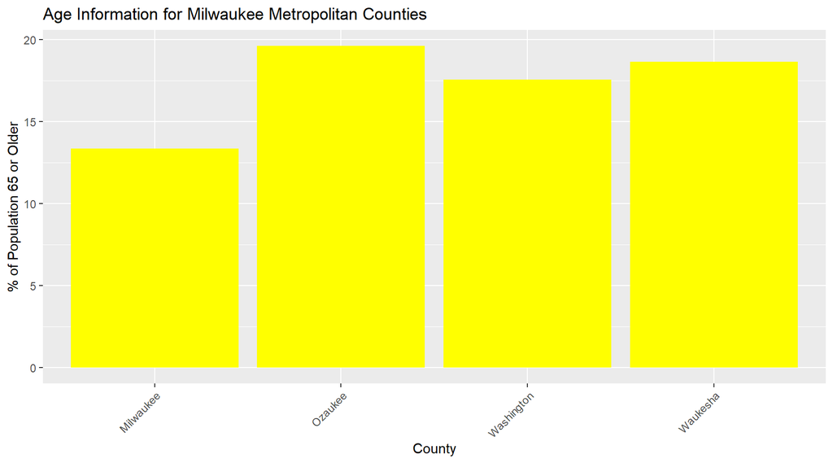

COVID is known to affect older people more profoundly, but Milwaukee County actually has fewer residents 65 or older, despite its greater case and death rates.

## GINI Index Data

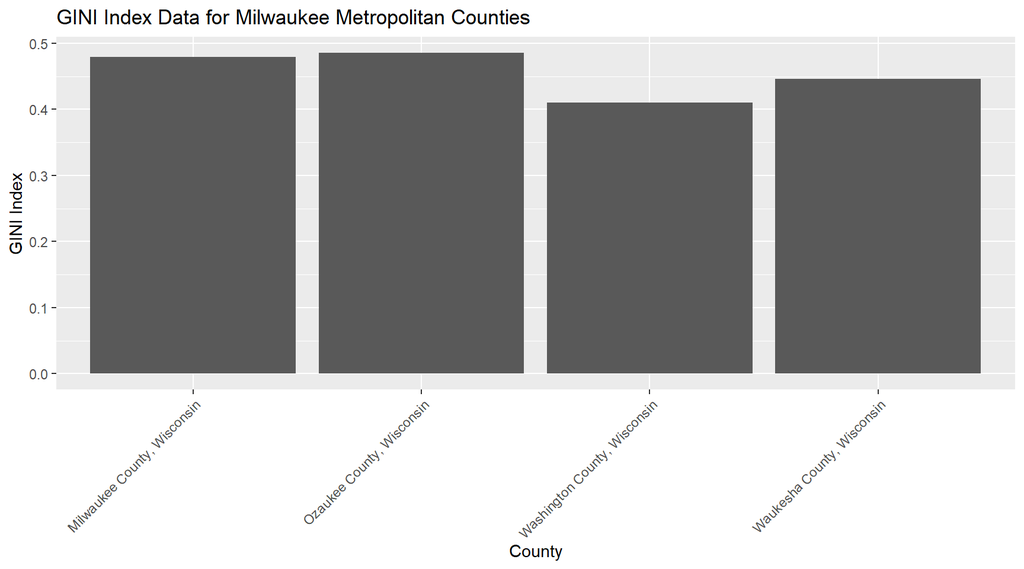

The GINI Index, which measures income inequality (closer to 1 means more income inequality) does not appear to be tied to COVID.

## Transportation Data

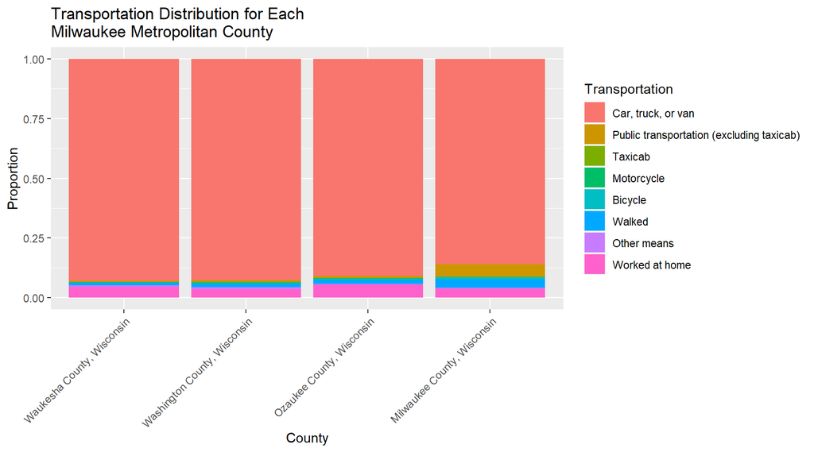

Residents in Milwaukee County use public transportation more than other Milwaukee metro counties, which could be tied to increased transmission of COVID.

## Occupation

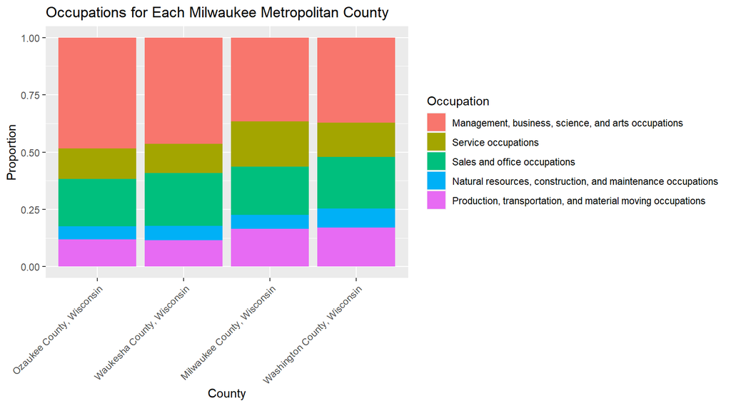

Occupation does not appear to be tied to COVID case and death rates.

## Citizenship

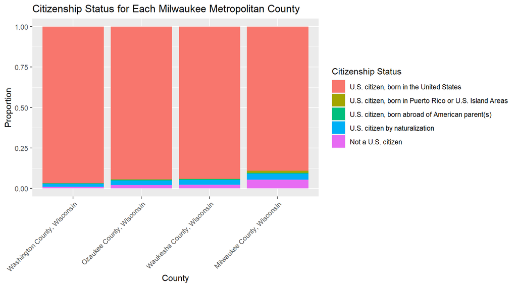

Marginalized communities, such as those not born in the US, are known to be more impacted by COVID. Milwaukee County also has a lower percentage of natural-born US citizens than other metropolitan counties.